# Project5

Spencer Muncey and Chenchao Zang

November 13, 2015

# Exploring U.S MPG data to create interesting visual representations for analysis SQL and R Studio

For this project, we looked at the Environmental Protection Agency’s [fuel economy data](https://www.fueleconomy.gov/feg/download.shtml) for every vehicle tested at the National Vehicle and Fuel Emissions Laboratory in Ann Arbor, Michigan since 1984. This dataset has data on almost 37,000 different vehicles, and includes many attributes to analyze. This is the R and SQL replication of the Tableau visualizations in Project 4. In addtion, we created our own dataset called CAR_Sales which contains the total number of cars sold in the US from 1984 to 2014. The numbers came from [this website.](http://www.statista.com/statistics/199974/us-car-sales-since-1951/)

```r
require("jsonlite")
require("RCurl")
# Loads the data from Fast Food table into Fast Food dataframe
# Change the USER and PASS below to be your UTEid
vehicles <- data.frame(fromJSON(getURL(URLencode('skipper.cs.utexas.edu:5001/rest/native/?query="select ATVTYPE,BARRELS08,BARRELSA08,CITY08,CITYA08,CO2TAILPIPEAGPM,CO2TAILPIPEGPM,COMB08,COMBA08,CYLINDERS,FUELCOST08,FUELCOSTA08,FUELTYPE,FUELTYPE1,FUELTYPE2,HIGHWAY08,HIGHWAYA08,HLV,HPV,LV2,LV4,MPGDATA,PV2,PV4,YEAR,MAKE,TRANY from VEHICLES"'),httpheader=c(DB='jdbc:oracle:thin:@sayonara.microlab.cs.utexas.edu:1521:orcl', USER='C##cs329e_sm44585', PASS='orcl_sm44585', MODE='native_mode', MODEL='model', returnDimensions = 'False', returnFor = 'JSON'), verbose = TRUE),))

summary(vehicles)
```

```
##     ATVTYPE        BARRELS08         BARRELSA08          CITY08
##  null   :33825   Min.   : 0.0599   Min.   : 0.0000   Min.   :  6.00
##  FFV    : 1280   1st Qu.:14.9643   1st Qu.: 0.0000   1st Qu.: 15.00
##  Diesel : 1018   Median :17.3375   Median : 0.0000   Median : 17.00
##  Hybrid :  416   Mean   :17.6101   Mean   : 0.2144   Mean   : 17.81
##  EV     :   95   3rd Qu.:20.5896   3rd Qu.: 0.0000   3rd Qu.: 20.00
##  CNG    :   50   Max.   :47.0683   Max.   :18.3043   Max.   :138.00
##  (Other):   66
##     CITYA08         CO2TAILPIPEAGPM  CO2TAILPIPEGPM       COMB08
##  Min.   :  0.0000   Min.   :  0.00   Min.   :   0.0   Min.   :  7.00
##  1st Qu.:  0.0000   1st Qu.:  0.00   1st Qu.: 401.0   1st Qu.: 16.00
##  Median :  0.0000   Median :  0.00   Median : 467.7   Median : 19.00
##  Mean   :  0.4855   Mean   : 17.77   Mean   : 475.5   Mean   : 20.05
##  3rd Qu.:  0.0000   3rd Qu.:  0.00   3rd Qu.: 555.4   3rd Qu.: 23.00
##  Max.   :127.0000   Max.   :719.00   Max.   :1269.6   Max.   :124.00
##
##     COMBA08          CYLINDERS       FUELCOST08    FUELCOSTA08
##  Min.   :  0.000   4      :14010   Min.   : 500   Min.   :   0.00
##  1st Qu.:  0.000   6      :12838   1st Qu.:1600   1st Qu.:   0.00
##  Median :  0.000   8      : 8099   Median :1950   Median :   0.00
##  Mean   :  0.546   5      :  766   Mean   :1968   Mean   :  91.73
##  3rd Qu.:  0.000   12     :  533   3rd Qu.:2300   3rd Qu.:   0.00
##  Max.   :117.000   3      :  200   Max.   :5900   Max.   :4000.00
##                    (Other):  304
##             FUELTYPE                 FUELTYPE1           FUELTYPE2
##  Regular        :24592   Diesel           : 1090   E85        : 1280
##  Premium        : 9506   Electricity      :   95   Electricity:   38
##  Gasoline or E85: 1164   Midgrade Gasoline:   61   Natural Gas:   20
##  Diesel         : 1090   Natural Gas      :   60   null       :35404
##  Premium or E85 :  116   Premium Gasoline : 9645   Propane    :    8
##  Electricity    :   95   Regular Gasoline :25799
##  (Other)        :  187
##    HIGHWAY08        HIGHWAYA08            HLV              HPV
##  Min.   :  9.00   Min.   :  0.0000   Min.   : 0.000   Min.   :  0.00
##  1st Qu.: 20.00   1st Qu.:  0.0000   1st Qu.: 0.000   1st Qu.:  0.00
##  Median : 24.00   Median :  0.0000   Median : 0.000   Median :  0.00
##  Mean   : 23.95   Mean   :  0.6506   Mean   : 2.036   Mean   : 10.49
##  3rd Qu.: 27.00   3rd Qu.:  0.0000   3rd Qu.: 0.000   3rd Qu.:  0.00
##  Max.   :111.00   Max.   :107.0000   Max.   :49.000   Max.   :195.00
##
##       LV2              LV4        MPGDATA        PV2
##  Min.   : 0.000   Min.   : 0.00   N:25512   Min.   :  0.00
##  1st Qu.: 0.000   1st Qu.: 0.00   Y:11238   1st Qu.:  0.00
##  Median : 0.000   Median : 0.00             Median :  0.00
##  Mean   : 1.856   Mean   : 6.19             Mean   : 13.68
##  3rd Qu.: 0.000   3rd Qu.:13.00             3rd Qu.:  0.00
##  Max.   :41.000   Max.   :55.00             Max.   :194.00
##
##       PV4              YEAR             MAKE                   TRANY
##  Min.   :  0.00   Min.   :1984   Chevrolet: 3705   Automatic 4-spd:11039
##  1st Qu.:  0.00   1st Qu.:1990   Ford     : 3042   Manual 5-spd   : 8283
##  Median :  0.00   Median :2000   Dodge    : 2498   Automatic 3-spd: 3151
##  Mean   : 33.74   Mean   :2000   GMC      : 2345   Automatic (S6) : 2413
##  3rd Qu.: 90.00   3rd Qu.:2009   Toyota   : 1863   Manual 6-spd   : 2326
##  Max.   :192.00   Max.   :2016   BMW      : 1600   Automatic 5-spd: 2184
##                                  (Other)  :21697   (Other)        : 7354
```

```r
require("jsonlite")
require("RCurl")

# Loads the data from Total Car Sales table into CAR_Sale dataframe
# Change the USER and PASS below to be your UTEid
CAR_Sale <- data.frame(fromJSON(getURL(URLencode('skipper.cs.utexas.edu:5001/rest/native/?query="select YEAR, CAR_SALE from CAR_SALE"'),httpheader=c(DB='jdbc:oracle:thin:@sayonara.microlab.cs.utexas.edu:1521:orcl', USER='C##cs329e_cz4795', PASS='orcl_cz4795', MODE='native_mode', MODEL='model', returnDimensions = 'False', returnFor = 'JSON'), verbose = TRUE),))

summary(CAR_Sale)
```

```
##       YEAR         CAR_SALE
##  Min.   :1984   Min.   : 5400890
##  1st Qu.:1992   1st Qu.: 7611158
##  Median :1999   Median : 8213113
##  Mean   :1999   Mean   : 8338861
##  3rd Qu.:2006   3rd Qu.: 8884120
##  Max.   :2014   Max.   :11404239
```

### A detailed explanation of each column that we used in the vehicles dataset:

- ATVTYPE - type of alternative fuel or advanced technology vehicle
- BARRELS08 - annual petroleum consumption in barrels for fuelType1
- BARRELSA08 - annual petroleum consumption in barrels for fuelType2
- CITY08 - city MPG for fuelType1
- CITYA08 - city MPG for fuelType2
- CO2TAILPIPEGPM - tailpipe CO2 in grams/mile for fuelType1
- CO2TAILPIPEAGPM - tailpipe CO2 in grams/mile for fuelType2
- COMB08 - combined MPG for fuelType1
- COMBA08 - combined MPG for fuelType2
- CYLINDERS - engine cylinders
- FUELCOST08 - annual fuel cost for fuelType1 ($)
- FUELCOSTA08 - annual fuel cost for fuelType2 ($)
- FUELTYPE - fuel type with fuelType1 and fuelType2 (if applicable)
- FUELTYPE1 - fuel type 1. For single fuel vehicles, this will be the only fuel. For dual fuel vehicles, this will be the conventional fuel
- FUELTYPE2 - fuel type 2. For dual fuel vehicles, this will be the alternative fuel (e.g. E85, Electricity, CNG, LPG). For single fuel vehicles, this field is not used
- HIGHWAY08 - highway MPG for fuelType1
- HIGHWAYA08 - highway MPG for fuelType2
- HLV - hatchback luggage volume (cubic feet)
- HPV - hatchback passenger volume (cubic feet)
- LV2 - 2 door luggage volume (cubic feet)
- LV4 - 4 door luggage volume (cubic feet)
- MPGDATA - has My MPG data
- PV2 - 2-door passenger volume (cubic feet)
- PV4 - 4-door passenger volume (cubic feet)
- TRANY - transmission
- YEAR - model year

### A detailed explanation of each column that we used in the Car_Sale dataset:

- YEAR - From January 1 to December 31
- CAR_SALE - Total cars sold in the US for that year

### Extract, Load, Transform (ELT) Script for uploading Vehicle dataset into Oracle

```
#Before running this R file make sure you set you working directory to where the CSV file located.

file_path <- "vehicles.csv"

df <- read.csv(file_path, stringsAsFactors = FALSE)

# Replace "." (i.e., period) with "_" in the column names.
names(df) <- gsub("\\.+", "_", names(df))

str(df) # Uncomment this and  run just the lines to here to get column types to use for getting the list of measures.


# Generate List of Measures
measures <- c("barrels08", "barrelsA08", "charge120","charge240","city08", "cityA08", "co2TailpipeAGpm", "co2TailpipeGpm", "comb08", "combA08", "fuelCost08", "fuelCostA08", "highway08", "highwayA08", "hlv","hpv", "lv2", "lv4", "pv2", "pv4")

# Get rid of special characters in each column.
# Google ASCII Table to understand the following:
for(n in names(df)) {
  df[n] <- data.frame(lapply(df[n], gsub, pattern="[^ -~]",replacement= ""))
}

dimensions <- setdiff(names(df), measures)

#dimensions
if( length(measures) > 1 || ! is.na(dimensions)) {
  for(d in dimensions) {
    # Get rid of " and ' in dimensions.
    df[d] <- data.frame(lapply(df[d], gsub, pattern="[\"']",replacement= ""))
    # Change & to and in dimensions.
    df[d] <- data.frame(lapply(df[d], gsub, pattern="&",replacement= " and "))
    # Change : to ; in dimensions.
    df[d] <- data.frame(lapply(df[d], gsub, pattern=":",replacement= ";"))
  }
}


# Get rid of all characters in measures except for numbers, the - sign, and period.dimensions
if( length(measures) > 1 || ! is.na(measures)) {
  for(m in measures) {
    df[m] <- data.frame(lapply(df[m], gsub, pattern="[^--.0-9]",replacement= ""))
  }
}

write.csv(df, paste(gsub(".csv", "", file_path), ".reformatted.csv", sep=""), row.names=FALSE, na = "")

tableName <- gsub(" +", "_", gsub("[^A-z, 0-9, ]", "", gsub(".csv", "", file_path)))
sql <- paste("CREATE TABLE", tableName, "(\n-- Change table_name to the table name you want.\n")
if( length(measures) > 1 || ! is.na(dimensions)) {
  for(d in dimensions) {
    sql <- paste(sql, paste(d, "varchar2(4000),\n"))
  }
}
if( length(measures) > 1 || ! is.na(measures)) {
  for(m in measures) {
    if(m != tail(measures, n=1)) sql <- paste(sql, paste(m, "number(38,4),\n"))
    else sql <- paste(sql, paste(m, "number(38,4)\n"))
  }
}
sql <- paste(sql, ");")
cat(sql)
```

### Extract, Load, Transform (ELT) Script for uploading Car_Sale dataset into Oracle

```
#Before running this R file make sure you set you working directory to where the CSV file located.

file_path <- "Car_Sale.csv"

df <- read.csv(file_path, stringsAsFactors = FALSE)

# Replace "." (i.e., period) with "_" in the column names.
names(df) <- gsub("\\.+", "_", names(df))

str(df) # Uncomment this and  run just the lines to here to get column types to use for getting the list of measures.


# Generate List of Measures
measures <- c("Car_Sale")

# Get rid of special characters in each column.
# Google ASCII Table to understand the following:
for(n in names(df)) {
  df[n] <- data.frame(lapply(df[n], gsub, pattern="[^ -~]",replacement= ""))
}

dimensions <- setdiff(names(df), measures)

#dimensions
if( length(measures) > 1 || ! is.na(dimensions)) {
  for(d in dimensions) {
    # Get rid of " and ' in dimensions.
    df[d] <- data.frame(lapply(df[d], gsub, pattern="[\"']",replacement= ""))
    # Change & to and in dimensions.
    df[d] <- data.frame(lapply(df[d], gsub, pattern="&",replacement= " and "))
    # Change : to ; in dimensions.
    df[d] <- data.frame(lapply(df[d], gsub, pattern=":",replacement= ";"))
  }
}


# Get rid of all characters in measures except for numbers, the - sign, and period.dimensions
if( length(measures) > 1 || ! is.na(measures)) {
  for(m in measures) {
    df[m] <- data.frame(lapply(df[m], gsub, pattern="[^--.0-9]",replacement= ""))
  }
}

write.csv(df, paste(gsub(".csv", "", file_path), ".reformatted.csv", sep=""), row.names=FALSE, na = "")

tableName <- gsub(" +", "_", gsub("[^A-z, 0-9, ]", "", gsub(".csv", "", file_path)))
sql <- paste("CREATE TABLE", tableName, "(\n-- Change table_name to the table name you want.\n")
if( length(measures) > 1 || ! is.na(dimensions)) {
  for(d in dimensions) {
    sql <- paste(sql, paste(d, "varchar2(4000),\n"))
  }
}
if( length(measures) > 1 || ! is.na(measures)) {
  for(m in measures) {
    if(m != tail(measures, n=1)) sql <- paste(sql, paste(m, "number(38,4),\n"))
    else sql <- paste(sql, paste(m, "number(38,4)\n"))
  }
}
sql <- paste(sql, ");")
cat(sql)
```

## Plot 1: Bar chart of Average MPG of vehicles based on transmission type using R

The first plot in Tableau is a bar chart with a reference line that looks at the effect of transmission type on highway and city MPG. Our first impression was that a manual transmission would produce the best MPG, but we were surprised to learn that an automatic 6-speed transmission produces not only the highest city MPG but also the highest highway MPG. Doing some [further research](http://www.edmunds.com/fuel-economy/five-myths-about-stick-shifts.html), we found that manual transmissions used to be more fuel efficent, but because of recent advances in automatic transmission technology, automatic transmissions have started to become more efficient in some cases.

### Plot 1: ggplot bar chart with reference line

```r
require(tidyr)
require(dplyr)
```

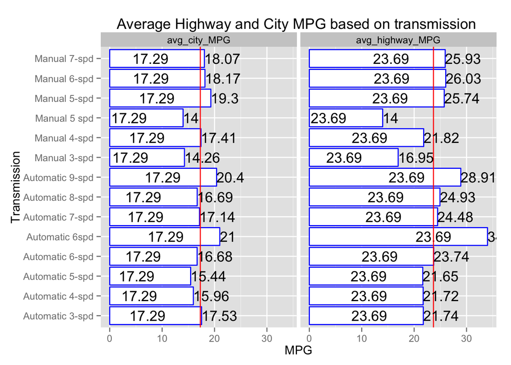

```r
require(ggplot2)
require(reshape2)
#R workflow
bar_chart <- vehicles %>% select(TRANY, HIGHWAY08, CITY08) %>% subset(TRANY %in% c("Automatic 3-spd", "Automatic 4-spd","Automatic 5-spd","Automatic 6-spd","Automatic 6spd","Automatic 7-spd", "Automatic 8-spd", "Automatic 9-spd", "Manual 3-spd", "Manual 4-spd", "Manual 5-spd", "Manual 5 spd", "Manual 6-spd", "Manual 7-spd")) %>% group_by(TRANY) %>% summarise(avg_city_MPG = mean(CITY08), avg_highway_MPG = mean(HIGHWAY08)) %>% melt(id.vars = c("TRANY")) %>% group_by(variable) %>% mutate(WINDOW_AVG_MPG = mean(value))
#Plot Function to generate bar chart with reference line and values
ggplot() +
  coord_cartesian() +
  scale_x_discrete() +
  scale_y_continuous() +
  facet_wrap(~variable) +
  labs(title='Average Highway and City MPG based on transmission ') +
  labs(x=paste("Transmission"), y=paste("MPG")) +
  layer(data=bar_chart,
        mapping=aes(x=TRANY, y=value),
        stat="identity",
        stat_params=list(),
        geom="bar",
        geom_params=list(colour="blue", fill="white"),
        position=position_dodge()
  ) + coord_flip() +
  layer(data=bar_chart,
        mapping=aes(x=TRANY, y=value, label=round(WINDOW_AVG_MPG, 2)),
        stat="identity",
        stat_params=list(),
        geom="text",
        geom_params=list(colour="black", hjust=2),
        position=position_identity()
  ) +
  layer(data=bar_chart,
        mapping=aes(yintercept = WINDOW_AVG_MPG),
        geom="hline",
        geom_params=list(colour="red")
  ) +
  layer(data=bar_chart,
        mapping=aes(x=TRANY, y=value, label=round(value, 2)),
        stat="identity",
        stat_params=list(),
        geom="text",
        geom_params=list(colour="black", hjust=0),
        position=position_identity()
  )
```

## Plot 2: Scatterplot of Combined MPG of all vehicles since 1984 using R

The next tableau plot is a scatterplot that looks at how the combined MPG of all cars since 1984 has evolved over the years. This plot was created to see if a trend was present. Initially, we were fairly confident that a positive trend would be present due to the recent advances in EV technology and general improvements in the efficency of internal combustion engines.

### Plot 2: ggplot scatterplot

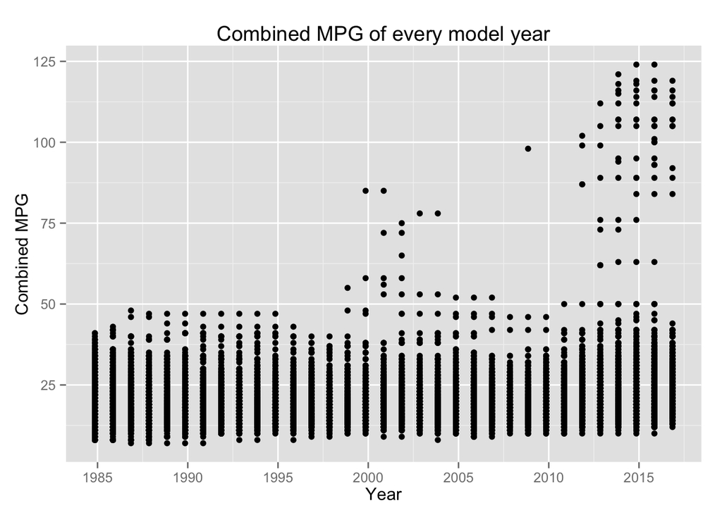

```r
# This file creates the scatterplot.
require(tidyr)
require(dplyr)
require(ggplot2)

# This selects only the comb08 and year columns whilte transforming the year column to a date
scatterplot <- vehicles %>% select(COMB08, YEAR) %>% transform(YEAR = as.Date(as.character(YEAR), "%Y"))

ggplot() +
  coord_cartesian() +
  scale_x_date() +
  scale_y_continuous() +
  labs(title="Combined MPG of every model year") +
  labs(x="Year", y="Combined MPG") +
  layer(data=scatterplot ,
        mapping=aes(x=YEAR, y=COMB08),
        stat="identity",
        stat_params=list(),
        geom="point",
        geom_params=list(),
        position=position_identity()
  )
```

## Plot 3: Cross tab of top 20 vehicle manufacturers and the MPG to passenger volume ratio for 2 door cars since 1984 using R

- Efficient and Spacious (KPI value > 2) - a manufacturer acheives this designation by offering a portfolio of 2 door cars that have a high combined MPG rating relative to the total passenger volume
- Average Efficiency and Space (1 <= KPI value < 2) - a manufacturer acheives this designation by offering a portfolio of 2 door cars that have a combined MPG rating relatively equal to the total passenger volume
- Not Efficient and Spacious - (KPI value < 1) a manufacturer acheives this designation by offering a portfolio of 2 door cars that have a low combined MPG relative to the total passenger volume

The interesting takeaway from this graph is that it visually represents a car company’s 2 door vehicle portfolio in terms of how efficent those cars are relative to how much passenger volume it has (which, for the purposes of our analysis, is used as a proxy for the size of the vehicle). It also shows that some car companies, like Chevy and Ford, have generally improved the efficency of their vehicles relative to how large the car is. There are also other companies, like Honda, that have newer vehicles achieving much worse efficieny to size ratios than the older models.

### Plot 3: ggplot cross tab for 2 door cars (PV2 KPI)

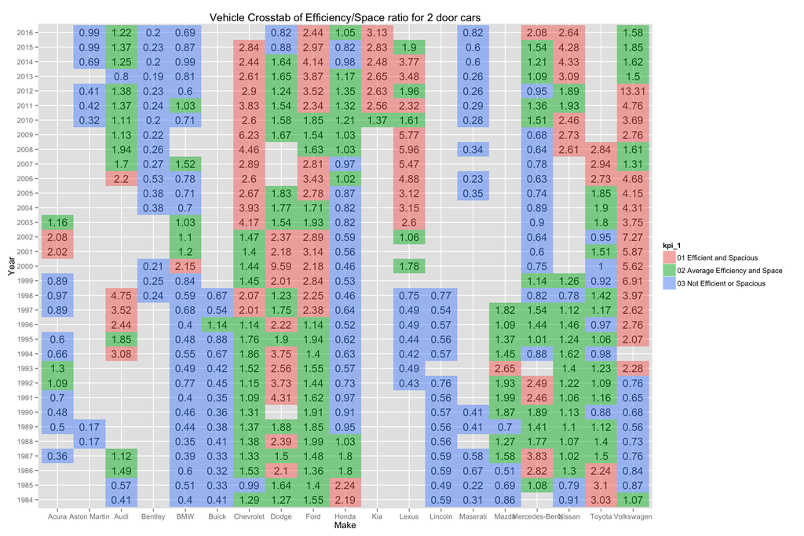

```r
require(jsonlite)
require(RCurl)
# The following is equivalent to creat a crosstab with two KPIs in Tableau"
MPG_PV2_KPI_LOW = 1
MPG_PV2_KPI_HIGH = 2
# The following is equivalent to creat a crosstab with two KPIs in Tableau"
crosstab <- vehicles %>% group_by(MAKE, YEAR) %>% summarize(sum_comb08 = sum(COMB08), sum_pv2 = sum(PV2),sum_pv4 = sum(PV4)) %>% mutate(ratio_1 = sum_comb08 / (sum_pv2))%>% mutate(ratio_2 = sum_comb08 / (sum_pv4)) %>% mutate(kpi_1 = ifelse(ratio_1 < MPG_PV2_KPI_LOW, '03 Not Efficient or Spacious', ifelse(ratio_1 <= MPG_PV2_KPI_HIGH, '02 Average Efficiency and Space', '01 Efficient and Spacious')))%>% mutate(kpi_2 = ifelse(ratio_2 < MPG_PV2_KPI_LOW, '03 Not Efficient or Spacious', ifelse(ratio_2 <= MPG_PV2_KPI_HIGH, '02 Average Efficiency and Space', '01 Efficient and Spacious'))) %>%filter(MAKE %in% c("Acura", "Aston Martin", "Audi", "Bentley", "BMW", "Buick", "Chevrolet", "Dodge", "Ferrari", "Ford", "Honda", "Kia", "Lincoln", "Lexus", "Maserati", "Mazda", "Mercedes-Benz", "Nissan", "Toyota", "Volkswagen")) %>% filter(ratio_1 != Inf, ratio_2 != Inf)

# This line turns the make and year columns into ordered factors.
crosstab <- crosstab %>% transform(MAKE = ordered(MAKE), YEAR = ordered(YEAR))
#This generates the PV2 plot with combined MPG
ggplot() +
  coord_cartesian() +
  scale_x_discrete() +
  scale_y_discrete() +
  labs(title='Vehicle Crosstab of Efficiency/Space ratio for 2 door cars') +
  labs(x=paste("Make"), y=paste("Year")) +
  layer(data=crosstab,
        mapping=aes(x=MAKE, y=YEAR, label=round(ratio_1, 2)),
        stat="identity",
        stat_params=list(),
        geom="text",
        geom_params=list(colour="black"),
        position=position_identity()
  ) +
  layer(data=crosstab,
        mapping=aes(x=MAKE, y=YEAR, fill=kpi_1),
        stat="identity",
        stat_params=list(),
        geom="tile",
        geom_params=list(alpha=0.50),
        position=position_identity()
  )
```

## Plot 4: Cross tab of top 20 vehicle manufacturers and the MPG to passenger volume ratio for 4 door cars since 1984 using R

The final tableau plot is a cross tab that provides a visual representation of which vehicle manufacturers produced 4 door cars that were efficent (high combined MPG) and spacious (as measured by the passenger volume of the vehicle). To calculate the ratio used for the KPI, we summed up the combined MPG of all the 4 door vehicles that a manufacturer produced during a model year and divided that by the total passenger volume for all those 4 door vehicles. The KPI categories are as follows:

- Efficient and Spacious (KPI value > 2) - a manufacturer acheives this designation by offering a portfolio of 4 door cars that have a high combined MPG rating relative to the total passenger volume
- Average Efficiency and Space (1 <= KPI value < 2) - a manufacturer acheives this designation by offering a portfolio of 4 door cars that have a combined MPG rating relatively equal to the total passenger volume
- Not Efficient and Spacious - (KPI value < 1) a manufacturer acheives this designation by offering a portfolio of 4 door cars that have a low combined MPG relative to the total passenger volume

The interesting takeaway from this graph is that it visually represents a car company’s 4 door vehicle portfolio in terms of how efficent those cars are relative to how much passenger volume it has (which, for the purposes of our analysis, is used as a proxy for the size of the vehicle).

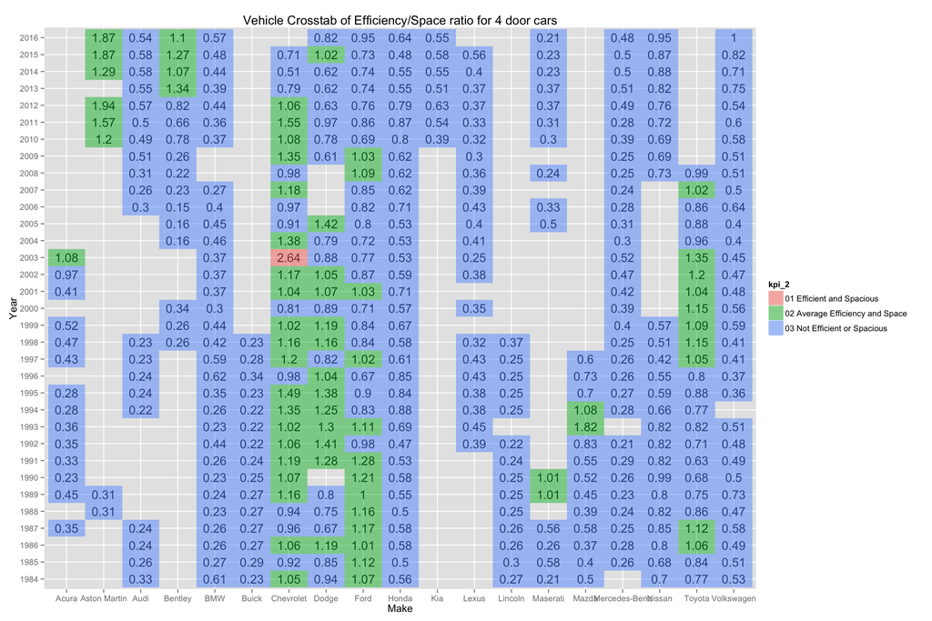

```r
#This generates the PV4 with combined MPG plot
ggplot() +
  coord_cartesian() +
  scale_x_discrete() +
  scale_y_discrete() +
  labs(title='Vehicle Crosstab of Efficiency/Space ratio for 4 door cars') +
  labs(x=paste("Make"), y=paste("Year")) +
  layer(data=crosstab,
        mapping=aes(x=MAKE, y=YEAR, label=round(ratio_2, 2)),
        stat="identity",
        stat_params=list(),
        geom="text",
        geom_params=list(colour="black"),
        position=position_identity()
  ) +
  layer(data=crosstab,
        mapping=aes(x=MAKE, y=YEAR, fill=kpi_2),
        stat="identity",
        stat_params=list(),
        geom="tile",
        geom_params=list(alpha=0.50),
        position=position_identity()
  )
```

## Plot 5: Data Blending of Vehicles and Car_Sales datasets

For this plot, we blended together the vehicles and car sales datasets based on the year. In other words, the vehicles dataset was grouped by the model year to get a count of the number of vehicles that the EPA tested for that model year and was blended with the Car Sales dataset based on the year. This gave us the ability to see what relationship existed between the number of cars the EPA tested and the number of cars sold in the United States for a given year.

In order to produce a good visualization, we had to filter the data to model years 2009 to 2014. Also, the number of cars tested by the EPA is significantly smaller than the total car sales for any given year so while it may not look like two bars are shown for each year, there is in fact one bar for the total number of cars tested by the EPA for a model year and another bar for the total number of cars sold for that model year.

We were surprised to learn that the EPA, on average from 2009 to 2014, tests roughly the same number of vehicles per model year, despite the fact that the number of vehicles sold during that time period has increased by almost 50%! This could be due to a number of things including perhaps the EPA has the testing capacity limit on the number of vehicles they can test per year.

### Plot 5: Data Blending in Tableau

[figure not shown]

### Plot 5: Data Blending in R

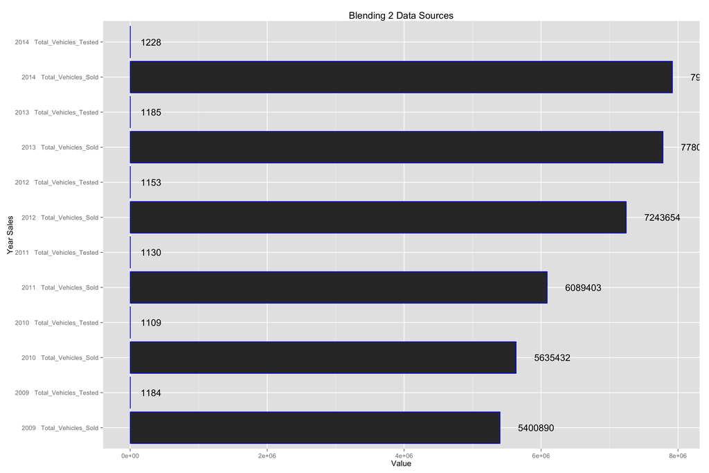

```r
require("jsonlite")
require("RCurl")
require(ggplot2)
require(dplyr)

# The following is equivalent to "04 Blending 2 Data Sources.twb"

df <- data.frame(fromJSON(getURL(URLencode(gsub("\n", " ", 'skipper.cs.utexas.edu:5001/rest/native/?query=
"select YEAR || \\\'   Total_Vehicles_Tested\\\' as measure_names, count(MAKE) as measure_values from VEHICLES
where YEAR between 2009 and 2014
group by YEAR
union all
select YEAR || \\\'   Total_Vehicles_Sold\\\' as measure_names, CAR_SALE as measure_values from CAR_SALE
where YEAR between 2009 and 2014
order by measure_names;"
')), httpheader=c(DB='jdbc:oracle:thin:@sayonara.microlab.cs.utexas.edu:1521:orcl', USER='C##cs329e_cz4795', PASS='orcl_cz4795', MODE='native_mode', MODEL='model', returnDimensions = 'False', returnFor = 'JSON'), verbose = TRUE)));

ggplot() +
  coord_cartesian() +
  scale_x_discrete() +
  scale_y_continuous() +
  #facet_wrap(~CLARITY, ncol=1) +
  labs(title='Blending 2 Data Sources') +
  labs(x=paste("Year Sales"), y=paste("Value")) +
  layer(data=df,
        mapping=aes(x=MEASURE_NAMES, y=MEASURE_VALUES),
        stat="identity",
        stat_params=list(),
        geom="bar",
        geom_params=list(colour="blue"),
        position=position_identity()
  ) + coord_flip() +
  layer(data=df,
        mapping=aes(x=MEASURE_NAMES, y=MEASURE_VALUES, label=round(MEASURE_VALUES)),
        stat="identity",
        stat_params=list(),
        geom="text",
        geom_params=list(colour="black", hjust=-0.5),
        position=position_identity()
  )
```